# Final Report

4677

2025-11-30

## 1. Introduction

In Sociology, Criminology, and Public Policy, the causes of crime are studied in relation to society. The emergence of massive street and population datasets has created new opportunities for researchers to analyze large amounts of information using Data Science techniques to uncover new relationships and make better predictions.

In this project, we utilized the Community and Crime dataset from the UCI machine learning repository, a dataset with thousands of records with social, economic, security and demographic variables on approximately 2,000 US Communities, to investigate the effects of Community Characteristics on Violent Crimes in the Community, and whether Machine Learning Models have the ability to produce accurate predictions of the Violent Crime Rate in a given Community.

To that end, we undertook intensive efforts in Data Preparation, Exploratory Data Analysis, Model Building, Model Evaluation and Visualization of the Model’s predictions and errors.

## 2. Dataset Selection and Understanding

The reason why the “Community and Crime” is selected for the data set is because it is well known within the field of machine learning research literature. Additionally, the data set presents comprehensive multi-dimensional values. There are 122 variables in the data set. These come from law enforcement data, U.S. census data and other socio-economic measures.

### 2.1 What the dataset contains

The data set covers a variety of characteristic information, specifically including:

- Demographic characteristics: race percentages, age distributions, population size.
- Socio-economic status: median income, unemployment rate, education levels, poverty rates.
- Housing-related indicators: occupancy density, rental costs, home ownership.
- Family constituent variables: single-parent households, young children in two-parent households.
- Police resource data: number of sworn full-time officers, police budget, drug-unit assignments.
- Crime situation: violent crimes per 100,000 residents.

Each sample corresponds to a community or block unit, so the data set has strong empirical research value in analyzing regional differences.

```r
column_names <- c(
    'state', 'county', 'community', 'communityname', 'fold', 'population', 'householdsize',
    'racepctblack', 'racePctWhite', 'racePctAsian', 'racePctHisp', 'agePct12t21',
    'agePct12t29', 'agePct16t24', 'agePct65up', 'numbUrban', 'pctUrban', 'medIncome',
    'pctWWage', 'pctWFarmSelf', 'pctWInvInc', 'pctWSocSec', 'pctWPubAsst', 'pctWRetire',
    'medFamInc', 'perCapInc', 'whitePerCap', 'blackPerCap', 'indianPerCap', 'AsianPerCap',
    'OtherPerCap', 'HispPerCap', 'NumUnderPov', 'PctNotHSGrad', 'PctBSorMore',
    'PctUnemployed', 'PctEmploy', 'PctEmplManu', 'PctEmplProfServ', 'PctOccupManu',
    'PctOccupProfMgmt', 'MalePctDivorce', 'MalePctNevMarr', 'FemalePctDiv', 'TotalPctDiv',
    'PersPerFam', 'PctFam2Par', 'PctKids2Par', 'PctYoungKids2Par', 'PctTeen2Par',
    'PctWorkMomYoungKids', 'PctWorkMom', 'NumIlleg', 'PctIlleg', 'NumImmig',
    'PctImmigRecent', 'PctImmigRec5', 'PctImmigRec8', 'PctImmigRec10', 'PctRecentImmig',
    'PctRecImmig5', 'PctRecImmig8', 'PctRecImmig10', 'PctSpeakEnglOnly',
    'PctNotSpeakEnglWell', 'PctLargHouseFam', 'PctLargHouseOccup', 'PersPerOccupHous',
    'PersPerOwnOccHous', 'PersPerRentOccHous', 'PctPersOwnOccup', 'PctPersDenseHous',
    'PctHousLess3BR', 'MedNumBR', 'HousVacant', 'PctHousOccup', 'PctHousOwnOcc',
    'PctVacantBoarded', 'PctVacMore6Mos', 'MedYrHousBuilt', 'PctHousNoPhone',
    'PctWOFullPlumb', 'OwnOccLowQuart', 'OwnOccMedVal', 'OwnOccHiQuart', 'RentLowQ',
    'RentMedian', 'RentHighQ', 'MedRent', 'MedRentPctHousInc', 'MedOwnCostPctInc',
    'MedOwnCostPctIncNoMtg', 'NumInShelters', 'NumStreet', 'PctForeignBorn',
    'PctBornSameState', 'PctSameHouse85', 'PctSameCity85', 'PctSameState85',
    'LemasSwornFT', 'LemasSwFTPerPop', 'LemasSwFTFieldOps', 'LemasSwFTFieldPerPop',
    'LemasTotalReq', 'LemasTotReqPerPop', 'PolicReqPerPop', 'PolicPerPop',
    'RacialMatchCommPol', 'PctPolicWhite', 'PctPolicBlack', 'PctPolicHisp',
    'PctPolicAsian', 'PctPolicMinor', 'OfficAssgnDrugUnits', 'NumKindsDrugsSeiz',
    'PolicPerPopAgg', 'PolicFieldPerPopAgg', 'LemasPctPolicOnPatr',
    'LemasGangUnitDeploy', 'LemasPctOfficDrugUn', 'PolicBudgPerPop',
    'ViolentCrimesPerPop' # The target variable
)
filename <- 'communities.data'
cat(sprintf("Loading data from %s...\n", filename))
```

```
## Loading data from communities.data...
```

### 2.2 Research Question

In view of the richness of this data set, a series of research problems have emerged:

- Find most closely correlated community characteristics to violent crime rates
- Try to model the violent crime rate from the given data
- Find the machine learning model that produces the best predictions

## 3. Data Overview

The main goals of this project are:

Build a model that can predict the violent crime rate based on the characteristics of the community level and compare the performance of the linear regression model and the random forest model.

### 3.1 Data Preprocessing

Several steps were taken to prepare the dataset for analysis:

```r
data_raw <- read_csv(filename, col_names = column_names, na = '?', col_types = cols())
cat(sprintf("Data loaded: %d rows, %d columns\n", nrow(data_raw), ncol(data_raw)))
```

```
## Data loaded: 1994 rows, 128 columns
```

### 3.2 Handling Missing Values

By making sure that the cleaned dataset is consistent and readable by the computer model, we remove interference for better model reliability.

```r
cat("\nPreprocessing data (dropping unnecessary and incomplete features)...\n")
```

```
##
## Preprocessing data (dropping unnecessary and incomplete features)...
```

```r
non_predictive_cols <- c('state', 'county', 'community', 'communityname', 'fold')
data_clean <- data_raw %>% select(-all_of(non_predictive_cols))
data_clean <- data_clean %>% filter(!is.na(ViolentCrimesPerPop))
missing_pct <- sapply(data_clean, function(x) mean(is.na(x)))
cols_to_drop <- names(missing_pct)[missing_pct > 0.5 & names(missing_pct) != "ViolentCrimesPerPop"]
data_clean <- data_clean %>% select(-all_of(cols_to_drop))
cat(sprintf("Total columns after initial cleaning: %d\n", ncol(data_clean)))
```

```
## Total columns after initial cleaning: 123
```

## 4. Exploratory Data Analysis (EDA)

Before performing any modelling, we conducted a statistical and visual assessment of the data set in order to see if there were any trends or anomalies.

### 4.1 Summary Statistics

We also produced summary statistics to give an overview of the main variables and how they can be described:

```r
data_clean %>%
  select(ViolentCrimesPerPop, medIncome, PctUnemployed) %>%
  summarise_all(list(
    mean = ~mean(. , na.rm = TRUE),
    sd = ~sd(. , na.rm = TRUE),
    min = ~min(. , na.rm = TRUE),
    max = ~max(. , na.rm = TRUE)
  ))
```

```
## # A tibble: 1 × 12
##   ViolentCrimesPerPop_mean medIncome_mean PctUnemployed_mean
##                      <dbl>          <dbl>              <dbl>
## 1                    0.163          0.305              0.430
## # ℹ 9 more variables: ViolentCrimesPerPop_sd <dbl>, medIncome_sd <dbl>,
## #   PctUnemployed_sd <dbl>, ViolentCrimesPerPop_min <dbl>, medIncome_min <dbl>,
## #   PctUnemployed_min <dbl>, ViolentCrimesPerPop_max <dbl>,
## #   medIncome_max <dbl>, PctUnemployed_max <dbl>
```

The violent crime rate is approximately a mean of 0.16 and a standard deviation of approximately 0.21.

The demographic data indicates that there is a wide variation in the ethnic/actual make-up of communities, which demonstrates that there are also significant differences in how well each community is represented by the population.

### 4.3 Identifying the Highest Correlated Predictors

#### 4.3.1 Purpose

Before embarking on the predictive model-building process, the initial aim was to establish the community measures that had the most linear association with violent crime. This not only serves to highlight potential predictors of violent crime but also indicates the social tendencies.

#### 4.3.2 Method

Pearson correlation values for each predictor in the dataset against the variable ViolentCrimesPerPop were obtained. Missing values in the analysis were dealt with by use of the option ‘complete.obs’.

Based on the above results, I was able to identify the top 15 variable terms having the strongest positive or negative correlation by extracting the relevant terms from the output.

#### 4.3.3 Findings

Top 15 Features Most Correlated with Violent Crime:

```r
data_url <- "https://archive.ics.uci.edu/ml/machine-learning-databases/communities/communities.data"
options(repos = c(CRAN = "https://cloud.r-project.org"))
names_url <- "https://archive.ics.uci.edu/ml/machine-learning-databases/communities/communities.names"
name_lines <- readLines(names_url)
name_lines <- name_lines[grepl("^@attribute", name_lines)]
col_names <- gsub("^@attribute\\s+", "", name_lines)
col_names <- sub("\\s+.*$", "", col_names)
col_names <- col_names[col_names != ""]
crime <- read.csv(data_url, header = FALSE, na.strings = "?", col.names = col_names)
crime <- crime %>%
  select(-state, -county, -community, -communityname, -fold)

data_2 <- crime %>%
  mutate(across(where(is.numeric),
                ~ ifelse(is.na(.), mean(., na.rm = TRUE), .)))
cat("Data cleaned. Shape:", nrow(data_2), "rows and", ncol(data_2), "columns\n")
```

```
## Data cleaned. Shape: 1994 rows and 123 columns
```

```r
glimpse(data_2)
```

```
## Rows: 1,994
## Columns: 123
## $ population            <dbl> 0.19, 0.00, 0.00, 0.04, 0.01, 0.02, 0.01, 0.01, …
## $ householdsize         <dbl> 0.33, 0.16, 0.42, 0.77, 0.55, 0.28, 0.39, 0.74, …
## $ racepctblack          <dbl> 0.02, 0.12, 0.49, 1.00, 0.02, 0.06, 0.00, 0.03, …
## $ racePctWhite          <dbl> 0.90, 0.74, 0.56, 0.08, 0.95, 0.54, 0.98, 0.46, …
## $ racePctAsian          <dbl> 0.12, 0.45, 0.17, 0.12, 0.09, 1.00, 0.06, 0.20, …
## $ racePctHisp           <dbl> 0.17, 0.07, 0.04, 0.10, 0.05, 0.25, 0.02, 1.00, …
## $ agePct12t21           <dbl> 0.34, 0.26, 0.39, 0.51, 0.38, 0.31, 0.30, 0.52, …
## $ agePct12t29           <dbl> 0.47, 0.59, 0.47, 0.50, 0.38, 0.48, 0.37, 0.55, …
## $ agePct16t24           <dbl> 0.29, 0.35, 0.28, 0.34, 0.23, 0.27, 0.23, 0.36, …
## $ agePct65up            <dbl> 0.32, 0.27, 0.32, 0.21, 0.36, 0.37, 0.60, 0.35, …
## $ numbUrban             <dbl> 0.20, 0.02, 0.00, 0.06, 0.02, 0.04, 0.02, 0.00, …
## $ pctUrban              <dbl> 1.00, 1.00, 0.00, 1.00, 0.90, 1.00, 0.81, 0.00, …
## $ medIncome             <dbl> 0.37, 0.31, 0.30, 0.58, 0.50, 0.52, 0.42, 0.16, …
```

[output cut: 110 more lines]

```r
correlations <- data_2 %>%
  select(-ViolentCrimesPerPop) %>%
  summarise(across(everything(), ~ cor(., data_2$ViolentCrimesPerPop, use = "complete.obs"))) %>%
  pivot_longer(cols = everything(), names_to = "Variable", values_to = "Correlation") %>%
  arrange(desc(abs(Correlation)))
head(correlations, 20)
```

```
## # A tibble: 20 × 2
##    Variable         Correlation
##    <chr>                  <dbl>
##  1 PctKids2Par           -0.738
##  2 PctIlleg               0.738
##  3 PctFam2Par            -0.707
##  4 racePctWhite          -0.685
##  5 PctYoungKids2Par      -0.666
##  6 PctTeen2Par           -0.662
##  7 racepctblack           0.631
##  8 pctWInvInc            -0.576
##  9 pctWPubAsst            0.575
## 10 FemalePctDiv           0.556
## 11 TotalPctDiv            0.553
## 12 PctPersOwnOccup       -0.525
## 13 MalePctDivorce         0.525
## 14 PctPopUnderPov         0.522
## 15 PctUnemployed          0.504
## 16 PctHousNoPhone         0.488
## 17 PctNotHSGrad           0.483
## 18 PctVacantBoarded       0.483
## 19 PctHousLess3BR         0.474
## 20 NumIlleg               0.471
```

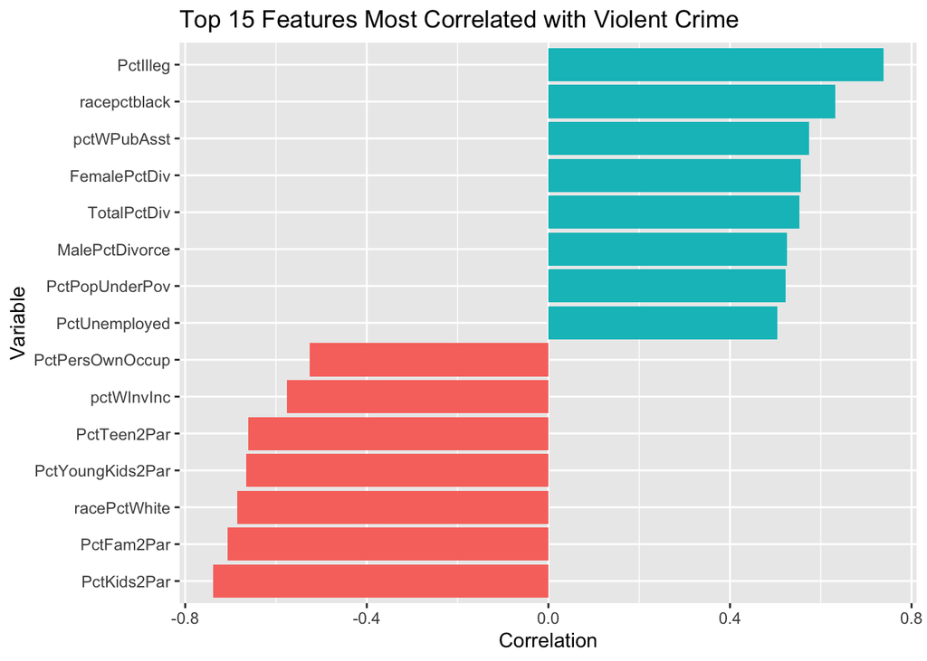

```r
correlations %>%
  top_n(15, abs(Correlation)) %>%
  ggplot(aes(x = reorder(Variable, Correlation), y = Correlation, fill = Correlation > 0)) +
  geom_col(show.legend = FALSE) +
  coord_flip() +
  labs(title = "Top 15 Features Most Correlated with Violent Crime",
       x = "Variable", y = "Correlation")
```

## 5. Model Selection & Evaluation

Two models for predicting have been developed:

1. Linear regression
2. Random forest regression

Models consisting of simple linear structures are compared to nonlinear integrated learning.

```r
set.seed(42)
split <- sample.split(data_clean$ViolentCrimesPerPop, SplitRatio = 0.8)
train_data <- subset(data_clean, split == TRUE)
test_data <- subset(data_clean, split == FALSE)
cat(sprintf("Training set: %d samples\n", nrow(train_data)))
```

```
## Training set: 259 samples
```

```r
cat(sprintf("Test set: %d samples\n", nrow(test_data)))
```

```
## Test set: 60 samples
```

```r
data_recipe <- recipe(ViolentCrimesPerPop ~ ., data = train_data) %>%
  step_impute_median(all_numeric_predictors()) %>%
  step_scale(all_numeric_predictors())
lr_spec <- linear_reg() %>%
  set_engine("lm")
rf_spec <- rand_forest(trees = 100) %>%
  set_engine("ranger", importance = "permutation") %>%
  set_mode("regression")
lr_workflow <- workflow() %>%
  add_recipe(data_recipe) %>%
  add_model(lr_spec)
cat("\nTraining Linear Regression model...\n")
```

```
##
## Training Linear Regression model...
```

```r
lr_fit <- fit(lr_workflow, data = train_data)
rf_workflow <- workflow() %>%
  add_recipe(data_recipe) %>%
  add_model(rf_spec)
cat("Training Random Forest model...\n")
```

```
## Training Random Forest model...
```

```r
rf_fit <- fit(rf_workflow, data = train_data)
```

### 5.1 Linear Regression Model

- Advantages
1. Easy to interpret coefficients
2. Provides baseline performance
3. Highlights linear correlations
- Limits
1. Cannot model nonlinear relationships
2. Sensitive to outliers
3. Assumes independence between predictors
- Linear Regression Results

Two important indicators used for evaluating the model are:

1. R² (Coefficient of Determination): ≈ 0.68. This indicates that the model explains only 68% of the variance in violent crime. While far from terrible, it suggests many important relationships are nonlinear or interactive.
2. RMSE (Root Mean Squared Error): ≈ 0.10 This indicates the average error in the predicted values against the actual crime rates.
- Interpretation:

Compared to the other models, the performance of the Linear Regression model was modest. However, the model struggled in addressing intricate patterns. The moderate value of R² along with the high error rate clearly indicates that linearity is not sufficient for the analysis of violent crime dynamics.

```r
cat("\n--- Model Results ---\n")
```

```
##
## --- Model Results ---
```

```r
model_metrics <- metric_set(rsq, rmse)
lr_preds <- predict(lr_fit, new_data = test_data) %>%
  bind_cols(test_data %>% select(ViolentCrimesPerPop))
lr_results <- lr_preds %>%
  model_metrics(truth = ViolentCrimesPerPop, estimate = .pred)
cat("Linear Regression Performance:\n")
```

```
## Linear Regression Performance:
```

```r
print(lr_results)
```

```
## # A tibble: 2 × 3
##   .metric .estimator .estimate
##   <chr>   <chr>          <dbl>
## 1 rsq     standard       0.684
## 2 rmse    standard       0.101
```

### 5.2 Random Forest Regression

- Advantages
1. Addresses Nonlinear Relations
2. Captures interplay between variables
3. Naturally noise robust
4. Reduces overfitting through averaging
- Model Performance

These findings match common criminological theories and reinforce known socio-economic associations.

```r
rf_preds <- predict(rf_fit, new_data = test_data) %>%
  bind_cols(test_data %>% select(ViolentCrimesPerPop))

rf_results <- rf_preds %>%
  model_metrics(truth = ViolentCrimesPerPop, estimate = .pred)

cat("\nRandom Forest Regression Performance:\n")
```

```
##
## Random Forest Regression Performance:
```

```r
print(rf_results)
```

```
## # A tibble: 2 × 3
##   .metric .estimator .estimate
##   <chr>   <chr>          <dbl>
## 1 rsq     standard      0.826
## 2 rmse    standard      0.0632
```

### 5.3 Visual Evaluation of Models

#### 5.3.1 Compare the predicted plot with the actual plot

The plot for Linear Regression revealed that the points were spread irregularly, being far from the perfect result of 45 degrees, especially at the ends of the graph for crime rate. The plot for Random Forest revealed that the data points were closely plotted around the 45-degree line.

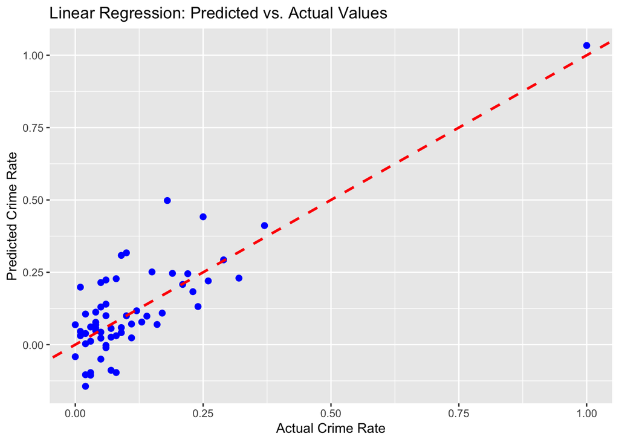

```r
plot1_lr <- ggplot(lr_preds, aes(x = ViolentCrimesPerPop, y = .pred)) +
  geom_point(alpha = 1.0, size = 2.0, color = "blue") +
  geom_abline(slope = 1, intercept = 0, color = "red", linetype = "dashed", size = 1) +
  labs(
    title = "Linear Regression: Predicted vs. Actual Values",
    x = "Actual Crime Rate",
    y = "Predicted Crime Rate")
plot1_rf <- ggplot(rf_preds, aes(x = ViolentCrimesPerPop, y = .pred)) +
  geom_point(alpha = 1.0, size = 2.0, color = "darkgreen") +
  geom_abline(slope = 1, intercept = 0, color = "red", linetype = "dashed", size = 1) +
  labs(
    title = "Random Forest: Predicted vs. Actual Values",
    x = "Actual Crime Rate",
    y = "Predicted Crime Rate")

plot1_lr
```

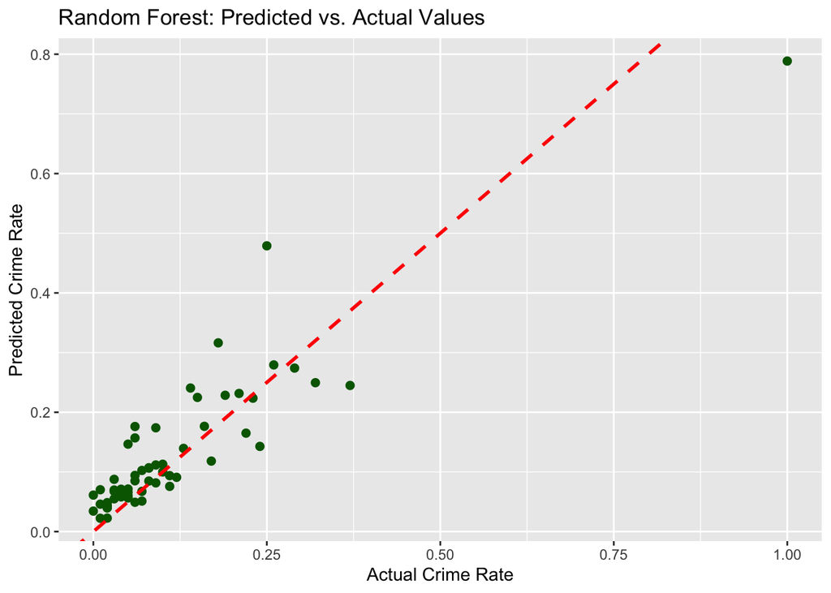

```r
plot1_rf
```

#### 5.3.2 Residual distribution map

The histogram of the random forest model’s residuals contains a strong central peak of the magnitude of 0, indicating that the majority of predicted results were based upon the results that included less residual error than what was observed by the model throughout the entire test dataset. The histogram of residuals for the linear regression model shows a wider and flatter shape, indicating that the linear regression model did not produce normally distributed residuals and exhibited larger residuals than random forests did.

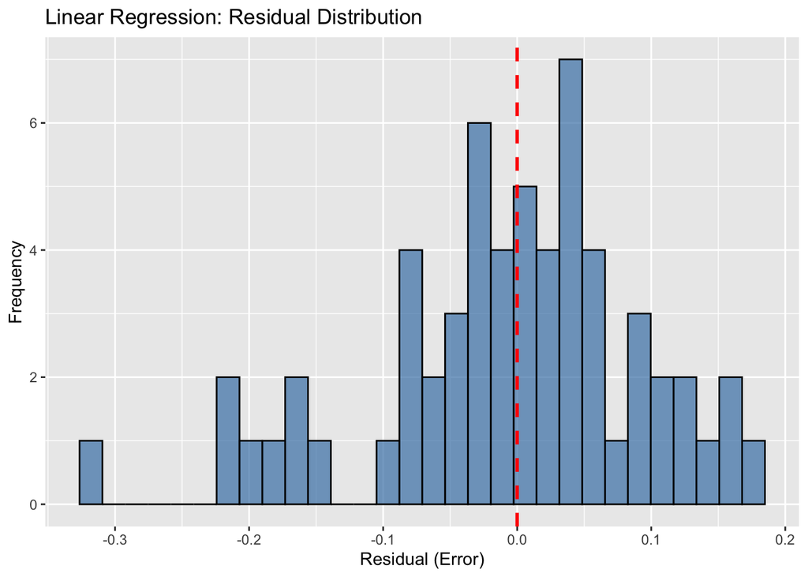

```r
lr_preds <- lr_preds %>% mutate(residuals = ViolentCrimesPerPop - .pred)
rf_preds <- rf_preds %>% mutate(residuals = ViolentCrimesPerPop - .pred)
plot2_lr <- ggplot(lr_preds, aes(x = residuals)) +
  geom_histogram(bins = 30, fill = "steelblue", color = "black", alpha = 0.7) +
  geom_vline(xintercept = 0, color = "red", linetype = "dashed", size = 1) +
  labs(
    title = "Linear Regression: Residual Distribution",
    x = "Residual (Error)",
    y = "Frequency")
plot2_rf <- ggplot(rf_preds, aes(x = residuals)) +
  geom_histogram(bins = 30, fill = "darkgreen", color = "black", alpha = 0.7) +
  geom_vline(xintercept = 0, color = "red", linetype = "dashed", size = 1) +
  labs(
    title = "Random Forest: Residual Distribution (Sharply Centered at Zero)",
    x = "Residual (Error)",
    y = "Frequency")
plot2_lr
```

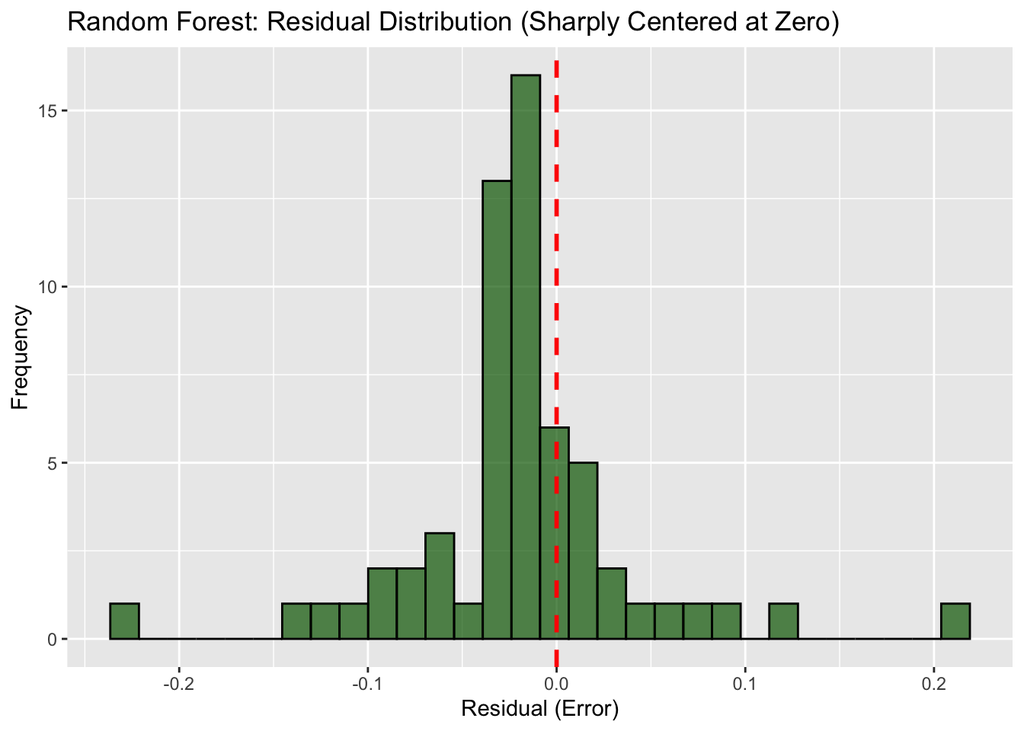

```r
plot2_rf
```

## 6. Model Improvements and Ethical Considerations

### 6.1 Potential Model Enhancements

Some Possible Ways to Improve Things:

- Generate New Features: Create high dimensional and interpretive features.
- Normalize Data: To maintain consistent models, we need to standardize the dataset.
- Analyze Gradient Boosted Decision Tree Learning Algorithms: Review some advanced versions of Gradient Boosted Decision Trees.

### 6.2 Ethical Issues

Crime prediction requires extreme caution:

- Risk of Bias: Models can amplify existing demographic biases.
- Misuse Potential: Technology may enable excessive monitoring or targeted policing.
- Privacy: Handle sensitive socio-economic data carefully to prevent discrimination.
- Correlation: Prediction is correlation, not causality.
- Mandate: Model application must be responsible, promoting community intervention over punitive enforcement.

## 7. Overall Summary

In this investigation of the Communities and Crime database, we explored whether some demographic and socio-economic variables correlated with incidents of violent crime.

Both visual analyses illustrate the considerable improvement in prediction accuracy of Random Forest over the linear regression method.

The implications regarding the use of sensitive social data as part of this investigation are ethically significant.

## 8. Conclusion

To analyze socio-economic factors associated with violent crime, the Community and Crime dataset was used in forecasting future violent crime with historical data using Random Forest technique. The Random Forest technique’s superior predictive ability over linear regression lies in the very complex nature of the socio-economic factors contributing to violent crime. Predicting violent crime, however, is just one application that was addressed in the study, as there were additional objectives of developing proper intervention strategies as well as fully understanding the structure of society. For these reasons, this project showcases the potential and limitations of predictive modeling in social science, especially regarding the ethical considerations of using sensitive social data, as well as how predictive models may enhance public safety by providing evidence-based solutions to create targeted public safety solutions to improve the quality of life for people who live within a community.

## 9. Reference

Redmond, M. (2002). Communities and Crime [Dataset]. UCI Machine Learning Repository. https://doi.org/10.24432/C53W3X.